# CMSC320-Final-Tutorial-Project

Jerry Qian & Harish Kumar

May 20, 2019

## Table Of Contents

1. The Rise of E-Sports
2. Data Analytics and E-Sports
3. League of Legends and Summoner’s Rift
4. The Dataset
5. Grabbing the Data
6. Observing and Managing the Data
7. Exploring the Data: Some Basic Summaries
8. Exploratory Data Analysis: Characteristics of Winning
9. Simple Machine Learning: Logistic Regression

## The Rise of E-Sports

For millennia, humans have embraced the adrenaline and thrill of competition; hunting, gathering, sport, and even war, are all testament to this. Today, civilization continues to glorify competition, as can be seen in global events (Olympics, Commonwealth games, etc.), sport leagues (Champions League, NFL, IPL, etc.), and more. In alliance with technological advancement, we are now witnessing the growth of a new kind of competitive arena: e-sports.

E-sports is a term for competitive video gaming. Players from all over the world compete individually or in teams with audiences akin to that of more “formal” sports (like soccer). What was considered a homely pastime, is now being considered a full-fledged sport with live streaming, worldwide fanfare, and heavy marketing; after all, to be a successful e-sports athlete, one must follow a regiment and lifestyle proportionally like that of other athletes.

Some video games that have a major e-sports presence include League of Legends (our focus), Overwatch, Fortnite, and FIFA.

To learn more about e-sports, check out [this CNN article](https://www.cnn.com/2018/08/27/us/esports-what-is-video-game-professional-league-madden-trnd/index.html).

## Data Analytics and E-Sports

Data analytics has become a major part of modern e-sports. Just like traditional field sports, individuals and teams craft gameplay strategies, commentators conduct game analysis, and audience members refer play records. All data production is automated by the electronic nature of video games, which results in massive corporas of gaming data.

With e-sports on a monumental rise, it is an exciting time for data analysis and e-sports to co-exist. What are the possibilities? For one, players can improve their performance by reflecting on their past performances; this is already possible in major e-sports video games, which have dedicated game analytics and other helpful services. Inconsistencies and problems within games can be figured out faster than ever before, to optimize play. So much more!

To learn more about the confluence between data analytics and e-sports, check out [this post from Intel](https://www.intel.co.uk/content/www/uk/en/it-management/cloud-analytic-hub/big-data-powered-esports.html).

## League of Legends and Summoner’s Rift

For this tutorial, we will be analysing a dataset of League of Legends matches. League of Legends is currently one of the most popular matchs in the world. It is a part of the multiplayer online battle arena (MOBA) genre where players battle it out, work together, and achieve objectives on an online map with many other players. There are multiple maps and matchmodes. We will be focusing on the most popular one used for esports, ranked, and competitive matchplay called Summoner’s Rift. This match can be highly competitive so insights will be useful in many aspects.

In Summoner’s Rift, each team is made of 5 players. Each player can choose to play a different champion (character) out of a pool of 140 champions. The players strategically spread out around the map. There are three lanes that connect the two sides (called Top, Middle, Bottom). Each lane is separated by a jungle filled with monsters and objectives. Please refer to the made below for a spatial understanding.

[figure not shown]

A map of summoner’s rift.

The objective is to destroy the enemy team’s nexus located in their base. Each side’s nexus is protected by 4 defensive towers that are placed in each of the lanes. The towers defend the nexus by attacking enemies in their range. Teams must work together to control the map to take down the 4 tiers of towers and destroy the enemy nexus. Furthermore, the nexus spawns computer controlled “minions” at regular intervals (waves) to aid the seige of the enemy base throughout the match. They blindly walk down the lanes and attack the first/closest enemy they see (including enemy minions). Inside the enemy base, there are three inhibitors, one for each lane. When a team destroys the opposing team’s inhibitor, the nexus begins to spawn “super minions” that deal significantly more damage and have a lot more health. Destroying the inhibitor allows teams to increase pressure on their opponents.

Inside the jungle, there are many important objectives that grant gold and bonuses. The three most important are Dragons, Rift Herald, and Baron Nashor. Slaying a Dragons grants bonuses such as more damage or more movespeed (depending on which type of dragon). Slaying the Rift Herald allows you to summon it in a lane to help seige the enemy base. Slaying Baron Nashor grants large damage boosts, empowered recalls, and offensive/defensive/movement speed bonuses to nearby minions. These three are highly contested objectives and can make or break a game.

Gold can be earned by each player throughout the game. Gold can be used to purchase items in the shop at base that offers different stats, bonuses, and abilities. Killing enemy minions, enemies players, jungle monsters, and towers grant varying amounts of gold.

This game can be highly competitive. There are countless strategies that can be used to out maneuver the opposing team. Each champion comes with a learning curve that separates the best players from the millions of players around the world.

To see an example of what types of strategies can go into gaining an advantage on opponents, watch this video: https://www.youtube.com/watch?v=qzNOSom-uB0 To learn more about the match, watch this video that describes league of legends in detail to beginners: https://www.youtube.com/watch?v=hOCEfU96AtU

## The Dataset

We got our dataset from https://www.kaggle.com/datasnaek/league-of-legends. It is around 3 megabytes. It contains 51.5k rows, each representing a match, and 61 columns/attributes.

## Grabbing the Data

We will turn the data into a data table that R can use for analysis. A *data table* is a row by column representation of all the data. Each row represents an **entity**, which is a real-world object, person, or concept; in the case of our dataset, the entity is a single League of Legends match. Now, each column represents an **attribute**, which is a characteristic for an entity. In our case, a LoL match can have an id, a duration, a winner, some statistics (like First Blood), and more.

Our data is stored locally. We create a string that describes the computer location of the dataset, which has been stored as a CSV file. A **Comma-seperated values** (CSV) file is just that, a bunch of values seperated by columns. The `read_csv()` method of R, parses out the commas, analyzes the values, and creates a data table that is much easier for us to handle when we do analysis. We store the result in our `lol` variable, which will become an identifier for the data table.

And since this is a huge data table, we only want to look at some of the values as a preview; we do this with the `head()` function.

```r
url <- 'data/games.csv'
lol <- read_csv(url)
head(lol)
```

```
## # A tibble: 6 x 61
##   gameId creationTime gameDuration seasonId winner firstBlood firstTower
##    <dbl>        <dbl>        <dbl>    <dbl>  <dbl>      <dbl>      <dbl>
## 1 3.33e9      1.50e12         1949        9      1          2          1
## 2 3.23e9      1.50e12         1851        9      1          1          1
## 3 3.33e9      1.50e12         1493        9      1          2          1
## 4 3.33e9      1.50e12         1758        9      1          1          1
## 5 3.33e9      1.50e12         2094        9      1          2          1
## 6 3.29e9      1.50e12         2059        9      1          2          2
## # ... with 54 more variables: firstInhibitor <dbl>, firstBaron <dbl>,
## #   firstDragon <dbl>, firstRiftHerald <dbl>, t1_champ1id <dbl>,
## #   t1_champ1_sum1 <dbl>, t1_champ1_sum2 <dbl>, t1_champ2id <dbl>,
## #   t1_champ2_sum1 <dbl>, t1_champ2_sum2 <dbl>, t1_champ3id <dbl>,
## #   t1_champ3_sum1 <dbl>, t1_champ3_sum2 <dbl>, t1_champ4id <dbl>,
## #   t1_champ4_sum1 <dbl>, t1_champ4_sum2 <dbl>, t1_champ5id <dbl>,
## #   t1_champ5_sum1 <dbl>, t1_champ5_sum2 <dbl>, t1_towerKills <dbl>,
## #   t1_inhibitorKills <dbl>, t1_baronKills <dbl>, t1_dragonKills <dbl>,
## #   t1_riftHeraldKills <dbl>, t1_ban1 <dbl>, t1_ban2 <dbl>, t1_ban3 <dbl>,
## #   t1_ban4 <dbl>, t1_ban5 <dbl>, t2_champ1id <dbl>, t2_champ1_sum1 <dbl>,
## #   t2_champ1_sum2 <dbl>, t2_champ2id <dbl>, t2_champ2_sum1 <dbl>,
## #   t2_champ2_sum2 <dbl>, t2_champ3id <dbl>, t2_champ3_sum1 <dbl>,
## #   t2_champ3_sum2 <dbl>, t2_champ4id <dbl>, t2_champ4_sum1 <dbl>,
## #   t2_champ4_sum2 <dbl>, t2_champ5id <dbl>, t2_champ5_sum1 <dbl>,
## #   t2_champ5_sum2 <dbl>, t2_towerKills <dbl>, t2_inhibitorKills <dbl>,
## #   t2_baronKills <dbl>, t2_dragonKills <dbl>, t2_riftHeraldKills <dbl>,
## #   t2_ban1 <dbl>, t2_ban2 <dbl>, t2_ban3 <dbl>, t2_ban4 <dbl>,
## #   t2_ban5 <dbl>
```

## Observing and Managing the Data

The remaining columns describe the champions (characters) that both teams used during the match.

Now, as data analysts we need to ask ourselves the question: Is the data tidy? That is, is the data stored in a format that is easily understandable for humans, easily processable for computers, and easily streamlined for analysis? To ensure this, we can follow **Tidy Data Principles**.

Envisioned by Hadley Wickham, the creator of the magnificent Tidyverse R package, the Tidy Data Principles promote three key features of rectangular data tables (like the ones we have).

1. Each attribute forms a column
2. Each entity forms a row
3. Only one entity forms a table

Lucky for us, our dataset follows all three of these principles! Each row is a match; each column is a characteristic about the match, and the table contans only match entities!

But just because our data is clean, does not mean we are done! Let’s see what else we can tidy up, to optimize our data analysis. First, it would be nice if we can see the creation time attribute in a more human-friendly date format. We will use the lubridate package to do this.

```r
lol <- lol %>%
  mutate("creationDate" = as_datetime(lol$creationTime))

head(lol$creationDate)
```

```
## [1] "49638-09-19 20:59:30 UTC" "49434-12-10 00:11:02 UTC"
## [3] "49641-04-10 06:28:30 UTC" "49640-11-27 00:26:36 UTC"
## [5] "49647-06-07 04:48:19 UTC" "49555-12-19 13:48:52 UTC"
```

Another way we can prepare the dataset for more optimized analysis, is by converting the match duration from seconds to minutes. We will create a new column with the converted duration.

```r
lol <- lol %>%
  mutate("durationMin" = lol$gameDuration / 60)

lol
```

```
## # A tibble: 51,490 x 63
##    gameId creationTime gameDuration seasonId winner firstBlood firstTower
##     <dbl>        <dbl>        <dbl>    <dbl>  <dbl>      <dbl>      <dbl>
##  1 3.33e9      1.50e12         1949        9      1          2          1
##  2 3.23e9      1.50e12         1851        9      1          1          1
##  3 3.33e9      1.50e12         1493        9      1          2          1
##  4 3.33e9      1.50e12         1758        9      1          1          1
##  5 3.33e9      1.50e12         2094        9      1          2          1
##  6 3.29e9      1.50e12         2059        9      1          2          2
##  7 3.31e9      1.50e12         1993        9      1          1          2
##  8 3.33e9      1.50e12         1334        9      1          1          1
##  9 3.32e9      1.50e12         1387        9      2          2          2
## 10 3.33e9      1.50e12         2681        9      2          2          2
## # ... with 51,480 more rows, and 56 more variables: firstInhibitor <dbl>,
## #   firstBaron <dbl>, firstDragon <dbl>, firstRiftHerald <dbl>,
## #   t1_champ1id <dbl>, t1_champ1_sum1 <dbl>, t1_champ1_sum2 <dbl>,
## #   t1_champ2id <dbl>, t1_champ2_sum1 <dbl>, t1_champ2_sum2 <dbl>,
## #   t1_champ3id <dbl>, t1_champ3_sum1 <dbl>, t1_champ3_sum2 <dbl>,
## #   t1_champ4id <dbl>, t1_champ4_sum1 <dbl>, t1_champ4_sum2 <dbl>,
## #   t1_champ5id <dbl>, t1_champ5_sum1 <dbl>, t1_champ5_sum2 <dbl>,
## #   t1_towerKills <dbl>, t1_inhibitorKills <dbl>, t1_baronKills <dbl>,
## #   t1_dragonKills <dbl>, t1_riftHeraldKills <dbl>, t1_ban1 <dbl>,
## #   t1_ban2 <dbl>, t1_ban3 <dbl>, t1_ban4 <dbl>, t1_ban5 <dbl>,
## #   t2_champ1id <dbl>, t2_champ1_sum1 <dbl>, t2_champ1_sum2 <dbl>,
## #   t2_champ2id <dbl>, t2_champ2_sum1 <dbl>, t2_champ2_sum2 <dbl>,
## #   t2_champ3id <dbl>, t2_champ3_sum1 <dbl>, t2_champ3_sum2 <dbl>,
## #   t2_champ4id <dbl>, t2_champ4_sum1 <dbl>, t2_champ4_sum2 <dbl>,
## #   t2_champ5id <dbl>, t2_champ5_sum1 <dbl>, t2_champ5_sum2 <dbl>,
## #   t2_towerKills <dbl>, t2_inhibitorKills <dbl>, t2_baronKills <dbl>,
## #   t2_dragonKills <dbl>, t2_riftHeraldKills <dbl>, t2_ban1 <dbl>,
## #   t2_ban2 <dbl>, t2_ban3 <dbl>, t2_ban4 <dbl>, t2_ban5 <dbl>,
## #   creationDate <dttm>, durationMin <dbl>
```

## Exploring the Data: Some Basic Summaries

Our data is now ready to be used for analysis! The next step in the data analysis pipeline is crucial: **Exploratory Data Analysis** (EDA). This is the process of doing some preliminary evaluations of trends and statistics in the data. Why do we do this? Well, apart from being a useful form of data analysis in its own right, EDA can guide us in the right direction, when we perform more heftier data analysis and machine learning. It helps us identify where the juicy trends are, and what components of the data to devote our resources to.

Let’s do some EDA ourselves. We shall start off by looking at some of the summary stats of our data. What is the mean playing duration of a match in Season 9. Let’s call the `mean()` function on our newly created minute duration column.

```r
mean(lol$durationMin)
```

```
## [1] 30.53938
```

So, the average duration of a Summoner’s Rift match is about 30 and a half minutes. How about we look at this further with a histogram? Let’s analyze the distribution of minute duration for a match. The `geom_histogram()` method asks for a parameter called `bins`; bins are bounds of data that we do the counting on. Obviously, it will statistically useless to count the instances of every single unique minute duration; we bin our values into small intervals, so that we can come up with more useful analyses. In this case, we split the minute duration values into 100 intervals/bins.

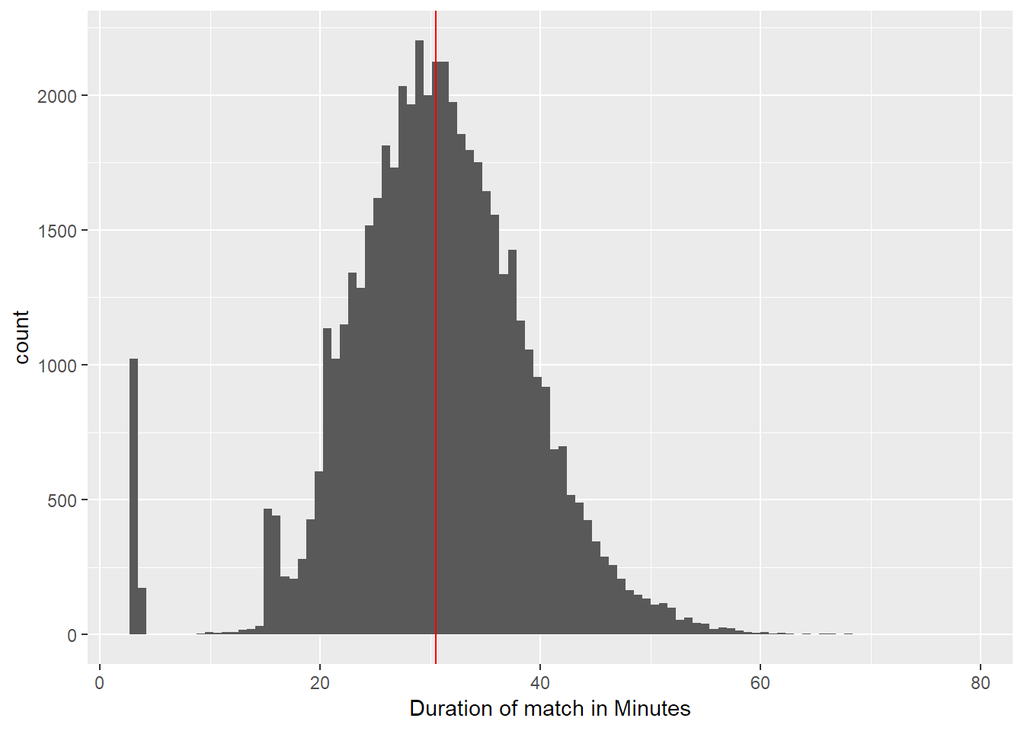

```r
lol %>%
  ggplot(aes(durationMin)) +
  geom_histogram(bins=100) +
  geom_vline(aes(xintercept=mean(lol$durationMin)), color="red") +
  labs(x = "Duration of match in Minutes")
```

The data follows a visually pleasing bell curve; this means the data is **normally distributed**. What does that mean, actually? Well, as the size of entities increases, data tends to clump around the mean. In the above graph, most matchs are played in around 30 minutes. As you move away from the mean, the number of matchs played tends to be smaller.

Now, we should note the spike at the start of the x-axis (that is, the matches that were finished in about 3 minutes). These are outliers that represent “remake” matches where one or more players left the game (or disconnected) before 3 minutes.

To make sure the outliers are not skewing the data, we measure the median, which is another statistic to find the central tendency. Let us look:

```r
median(lol$durationMin)
```

```
## [1] 30.55
```

```r
lol <- lol[which(lol$durationMin > 5),]
head(lol)
```

```
## # A tibble: 6 x 63
##   gameId creationTime gameDuration seasonId winner firstBlood firstTower
##    <dbl>        <dbl>        <dbl>    <dbl>  <dbl>      <dbl>      <dbl>
## 1 3.33e9      1.50e12         1949        9      1          2          1
## 2 3.23e9      1.50e12         1851        9      1          1          1
## 3 3.33e9      1.50e12         1493        9      1          2          1
## 4 3.33e9      1.50e12         1758        9      1          1          1
## 5 3.33e9      1.50e12         2094        9      1          2          1
## 6 3.29e9      1.50e12         2059        9      1          2          2
## # ... with 56 more variables: firstInhibitor <dbl>, firstBaron <dbl>,
## #   firstDragon <dbl>, firstRiftHerald <dbl>, t1_champ1id <dbl>,
## #   t1_champ1_sum1 <dbl>, t1_champ1_sum2 <dbl>, t1_champ2id <dbl>,
## #   t1_champ2_sum1 <dbl>, t1_champ2_sum2 <dbl>, t1_champ3id <dbl>,
## #   t1_champ3_sum1 <dbl>, t1_champ3_sum2 <dbl>, t1_champ4id <dbl>,
## #   t1_champ4_sum1 <dbl>, t1_champ4_sum2 <dbl>, t1_champ5id <dbl>,
## #   t1_champ5_sum1 <dbl>, t1_champ5_sum2 <dbl>, t1_towerKills <dbl>,
## #   t1_inhibitorKills <dbl>, t1_baronKills <dbl>, t1_dragonKills <dbl>,
## #   t1_riftHeraldKills <dbl>, t1_ban1 <dbl>, t1_ban2 <dbl>, t1_ban3 <dbl>,
## #   t1_ban4 <dbl>, t1_ban5 <dbl>, t2_champ1id <dbl>, t2_champ1_sum1 <dbl>,
## #   t2_champ1_sum2 <dbl>, t2_champ2id <dbl>, t2_champ2_sum1 <dbl>,
## #   t2_champ2_sum2 <dbl>, t2_champ3id <dbl>, t2_champ3_sum1 <dbl>,
## #   t2_champ3_sum2 <dbl>, t2_champ4id <dbl>, t2_champ4_sum1 <dbl>,
## #   t2_champ4_sum2 <dbl>, t2_champ5id <dbl>, t2_champ5_sum1 <dbl>,
## #   t2_champ5_sum2 <dbl>, t2_towerKills <dbl>, t2_inhibitorKills <dbl>,
## #   t2_baronKills <dbl>, t2_dragonKills <dbl>, t2_riftHeraldKills <dbl>,
## #   t2_ban1 <dbl>, t2_ban2 <dbl>, t2_ban3 <dbl>, t2_ban4 <dbl>,
## #   t2_ban5 <dbl>, creationDate <dttm>, durationMin <dbl>
```

Let’s make the same histogram to make sure our dropping of values happened successfully.

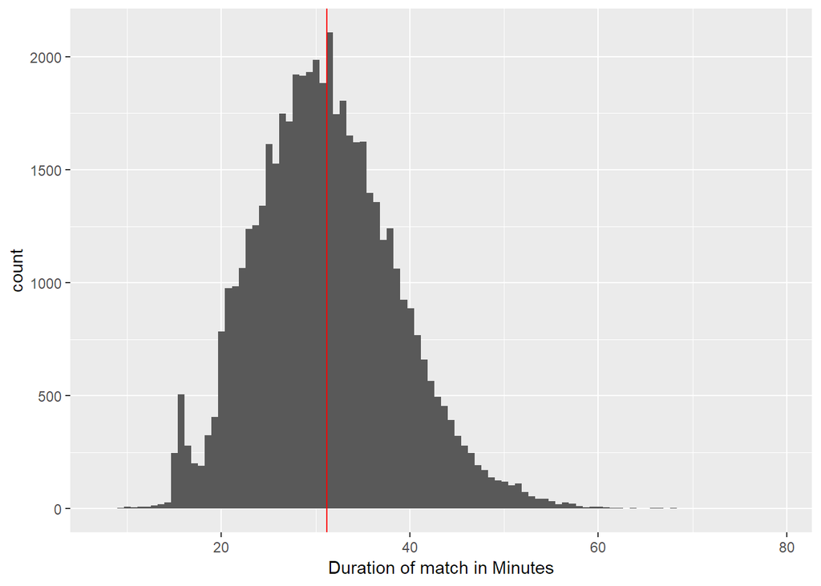

```r
lol %>%
  ggplot(aes(durationMin)) +
  geom_histogram(bins=100) +
  geom_vline(aes(xintercept=mean(lol$durationMin)), color="red") +
  labs(x = "Duration of match in Minutes")
```

Looks more like it!

Remember that data analysis is a cyclic process; at any step of the way, an astute data analyst should be prepared to go back and modify. Data analysis is all about optimization, and we should always strive for the best continuously, in our results!

What is the distribution of Team 1 and Team 2 wins across all 50,000-some matchs? We will create a bar plot to check this out; it will count the number of times Team 1 has won, versus Team 2.

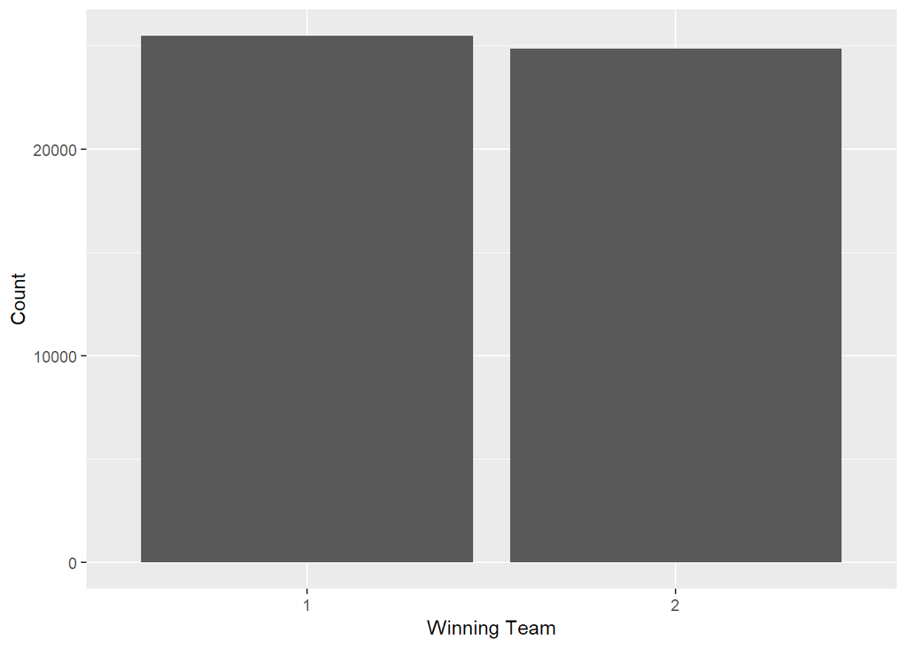

```r
lol %>%
  ggplot(aes(factor(winner))) +
  geom_bar() +
  labs(x="Winning Team", y="Count")
```

It’s nice to know that our data is pretty evenly distributed for both Team 1 and Team 2 wins; this means we are dealing with little skew towards either team, when doing our analysis.

## Exploratory Data Analysis: Characteristics of Winning

Now, let’s get to the mission: what characteristics define a winning team? We are going to heftier machine learning on it later, but for now, we will look at trends with EDA.

### First Blood and Winning

Well, we have some characteristics to look at: What is the win rate of a team when they achieve first blood? To elaborate, “first blood” is when a team secures the first kill of the match. Of course, it would be expected to be advantageous for a team to kill an enemy first, so that they can gain strong position early in the match with bonus gold and time with no opponent to contest.

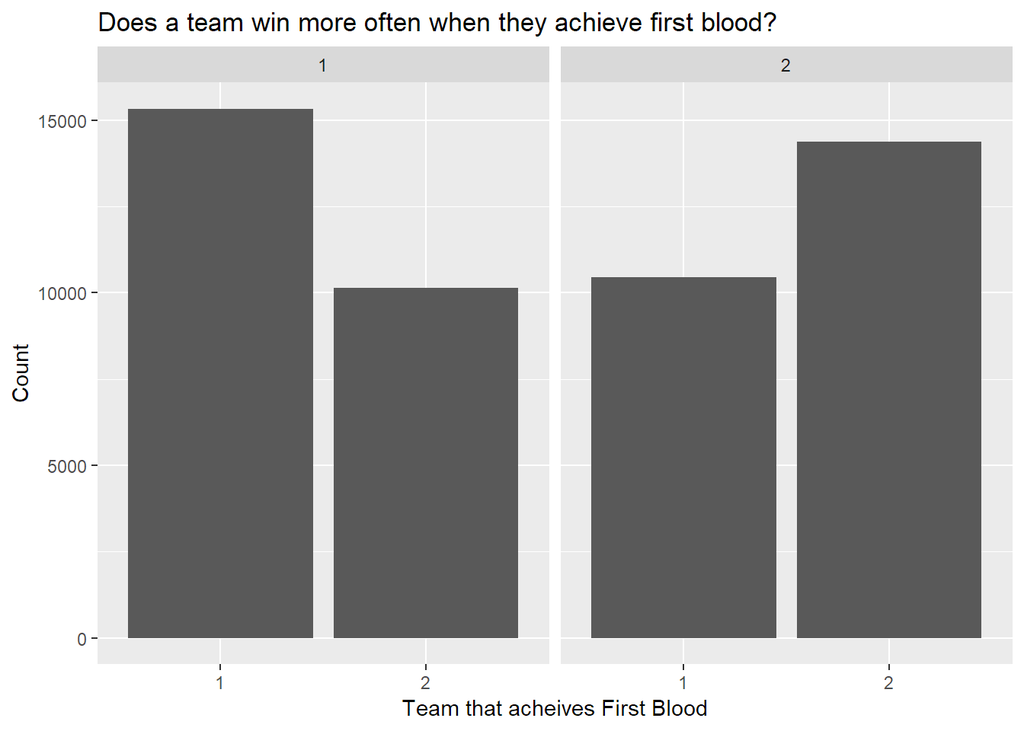

```r
lol %>%
  ggplot(aes(factor(firstBlood))) +
  geom_bar() +
  facet_wrap(~winner) +
  labs(x="Team that acheives First Blood", y="Count") +
  ggtitle("Does a team win more often when they achieve first blood?")
```

To clarify the format of the above plots, we used the `facet_wrap()` function to split the data into two groups: team 1 winning, and team 2 winning. We then count the number of instances of first blood for both teams, given the condition of winning.

In accordance with our assumptions, the team that achieves first blood has a higher chance of winning. Killing an enemy early in the match allows a team to set up a stronger stance throughout the match, with a gold lead and only 4 opponents defending.

### First Tower

Another metric that we look at is “first tower”: which team destroys one of the opponent’s towers first? Remember that towers are an impediment on the team’s path to the enemy nexus; destroying the first one can set a team up nicely to win. Now, is this assumption correct?

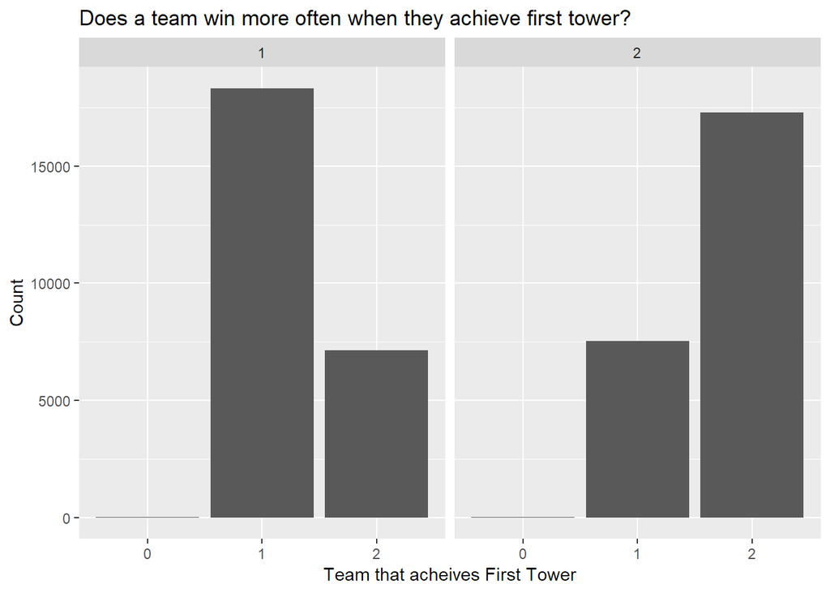

```r
lol %>%
  ggplot(aes(factor(firstTower))) +
  geom_bar() +
  facet_wrap(~winner) +
  labs(x="Team that acheives First Tower", y="Count") +
  ggtitle("Does a team win more often when they achieve first tower?")
```

Indeed, we are right in our assumptions! By destroying an enemy tower first, a team gains a strong advantage over the opposing team. It gets more map pressure, gold, and the enemies lose the security of hiding behind their towers.

### First Inhibitor

To reiterate, the inhibitor keeps the enemy team from spawning/creating what are known as *super minions*, which are harmful non-player characters (NPCs). Destroying one should be a boon for the team, right?

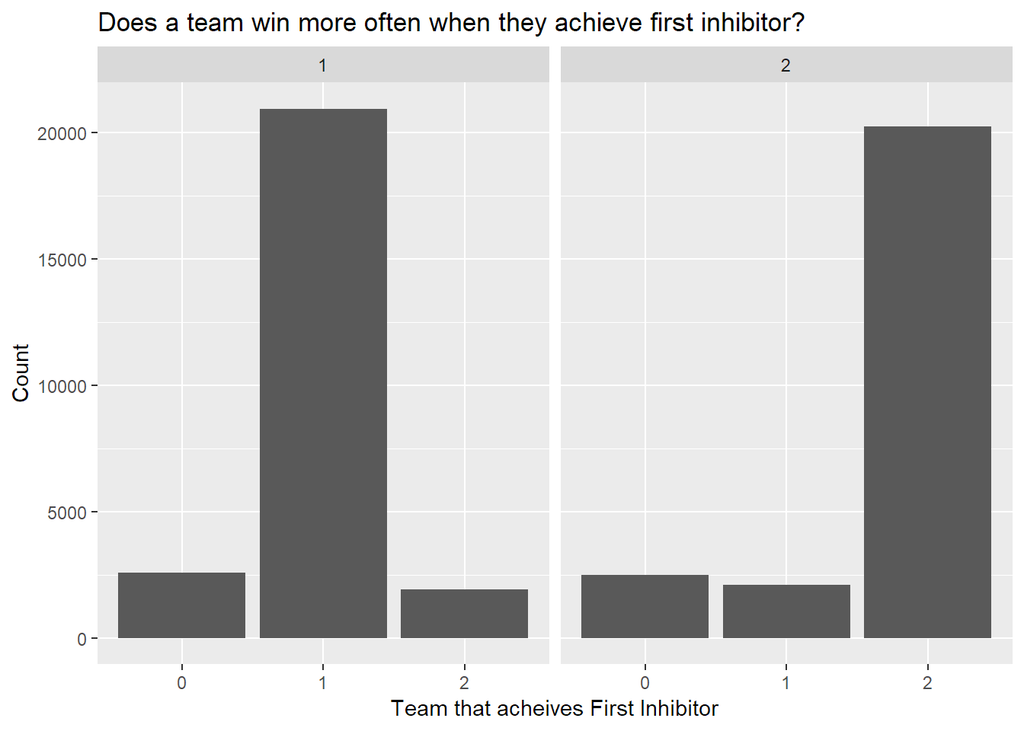

```r
lol %>%
  ggplot(aes(factor(firstInhibitor))) +
  geom_bar() +
  facet_wrap(~winner) +
  labs(x="Team that acheives First Inhibitor", y="Count") +
  ggtitle("Does a team win more often when they achieve first inhibitor?")
```

Correct! And by what a margin! Destroying an enemy team’s inhibitor can be a major turning point during the match. It allows the team to spawn super minions that push lanes and seige the enemy base. Note how getting first inhibitor is a extremely strong indicator of an ultimate victory. This is because the inhibitor is inside the enemy base. To destroy it, the team would have to be winning hard enough to even be in their base!

### First Baron

*Baron Nashor* is a powerful neutral enemy within the arena of Summoner’s Rift; it is neutral because it favors neither team. Killing it will grant a team-wide damage, recall, and minion power-up for a couple of minutes. So it is expected that a team killing the Baron first will have an edge, right?

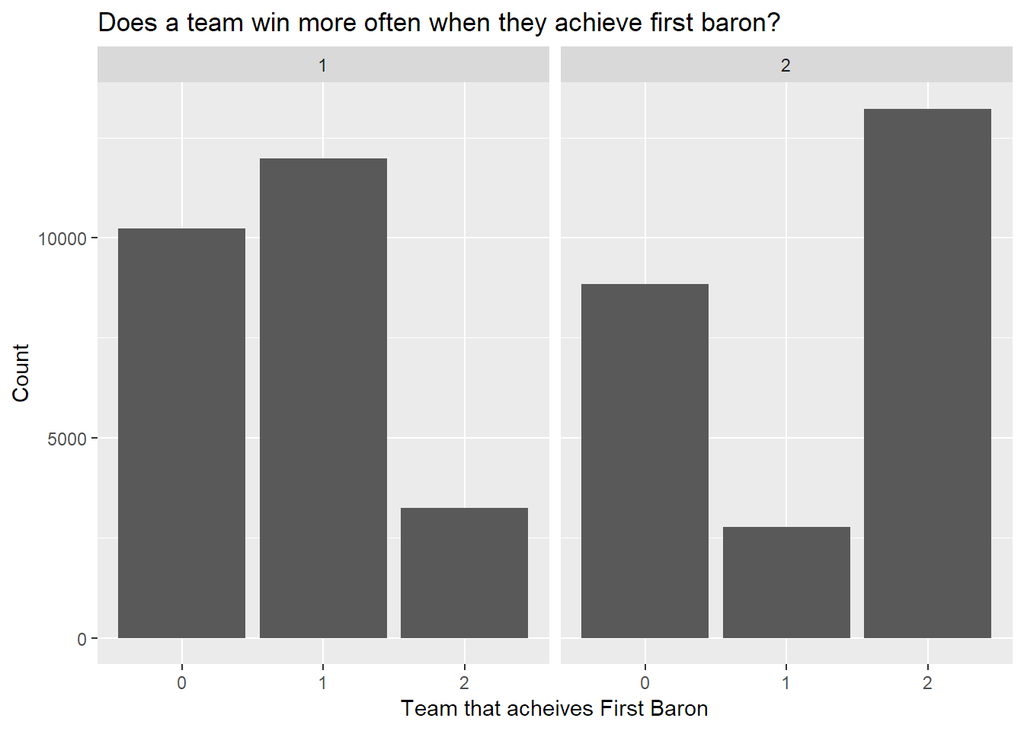

```r
lol %>%
  ggplot(aes(factor(firstBaron))) +
  geom_bar() +
  facet_wrap(~winner) +
  labs(x="Team that acheives First Baron", y="Count") +
  ggtitle("Does a team win more often when they achieve first baron?")
```

The above graph shows that when a team kills the baron, it has a higher chance of winning. Now, there also seems to be alot of ‘neithers’, or zeroes. This means neither team killed the baron at any point in the match; this is understandable, because killing the baron is no easy task. Usually, teams need to group us as five to slay it together. Ontop of that, the opposing team will usually contest the baron, which means they will try to fight your team for it. Often times, the team attempting to slay the baron are low in health and decide the disengage it when the opposing team tries to contest. But considering matchs where the baron was killed, the team that killed it first often prevailed as the winners.

### First Dragon

Dragons are like miniature barons; killing them offers more temporary but nevertheless useful power ups. Killing the first dragon is a good way to put one’s team ahead. Let’s see if that is the case.

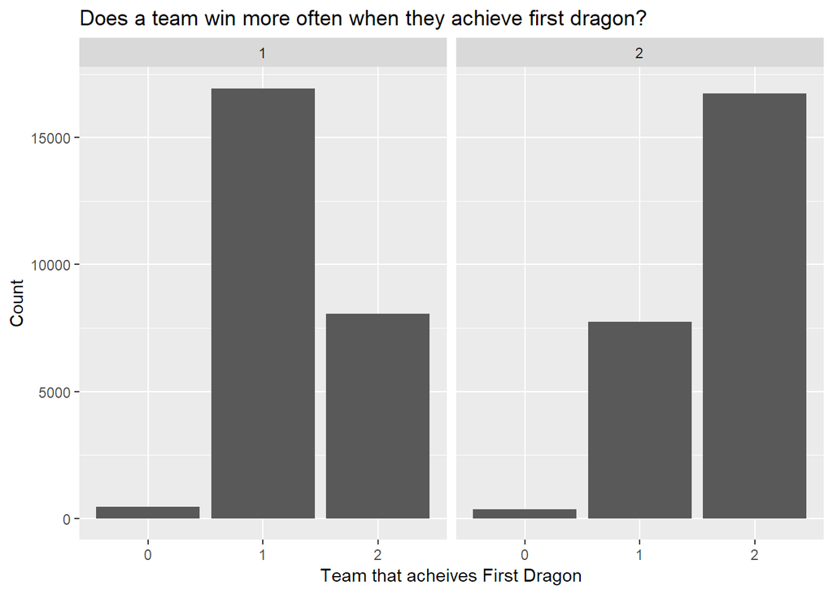

```r
lol %>%
  ggplot(aes(factor(firstDragon))) +
  geom_bar() +
  facet_wrap(~winner) +
  labs(x="Team that acheives First Dragon", y="Count") +
  ggtitle("Does a team win more often when they achieve first dragon?")
```

It is more easier to kill a dragon, hence the low number of ‘neithers’. But once again, teams that achieve first dragon are more likely to win than the other team. Killing the first dragon usually indicates that the team has control over the bottom side jungle (where the dragon pit is located) which is crucial for victory.

### First Rift Herald

Finally, we will look at the *Rift Herald*, which is another monster within the arena. Killing it allows the team to summon the Rift Herald in a lane to help seige towers. It is important to note that this monster automatically despawns at 20 minutes into the match (which means teams must kill it beforehand).

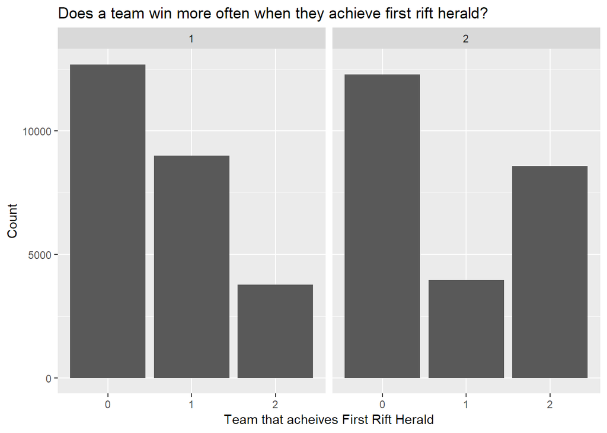

```r
lol %>%
  ggplot(aes(factor(firstRiftHerald))) +
  geom_bar() +
  facet_wrap(~winner) +
  labs(x="Team that acheives First Rift Herald", y="Count") +
  ggtitle("Does a team win more often when they achieve first rift herald?")
```

Woah! Remember that I said the Rift Herald despawns 20 minutes into the match. There are more instances where neither team defeats the Rift Heralds, but the matches in which it is defeated, the slaying team tends to be victorious. This makes sense because summoning the Rift Herald usually means the team destroys a tower with it.

Okay, we are done with our exploratory data analysis. It is time to delve into more sophisticated analysis and machine learning!

## Simple Machine Learning: Logistic Regression

```r
library(ISLR)
```

```r
library(dplyr)
library(broom)
library(ggplot2)
```

Machine learning is powerful as it can take large amounts of data and make predictions on the FUTURE! Fitting a machine learning model gives us a tool to gain insights on what has not happened yet based on current stats of a match. For example, we can train a machine learning model to predict which team will win based off of which team captures objectives first. The simplest machine learning strategy is linear regression! Fitting this model essentially gives us a line of best fit for the data.

Not so fast! Linear regression will not work on these values! Take a look at what happens when we try to put “win” vs “first blood” in a scatterplot.

### Why not Linear Regression?

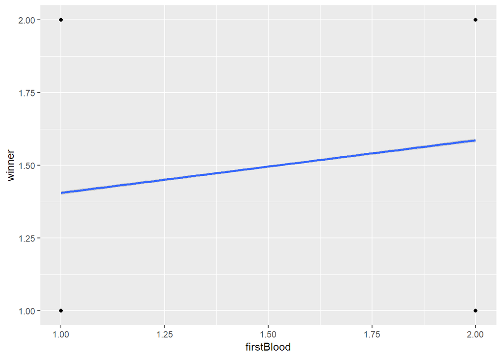

```r
ggplot(lol, aes(x=firstBlood, y=winner)) + geom_point() + geom_smooth(method="lm")
```

As you can see, the outcome of a match is binary: win or loss. The regression line does not have significant meaning. We are unable to do any linear regression to predict the winning team. However, this is perfect for logistic regression! We will be using multiple logistic regression because there are multiple predictor attributes (team with first blood, number of towers, etc).

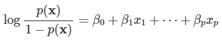

Equation for multiple logistic regression.

p(x) represents the probability of the outcome to happen (1). In our case this would be team 2 winning. The x_i’s represent the value of each predictor used. For us, this could be which team got first blood or the total number of towers a certain team has destroyed. The beta values are the coefficients to the predictors. These make up our model. To learn more about logistic regression, please visit this link: http://www.hcbravo.org/IntroDataSci/bookdown-notes/linear-models-for-classification.html

```r
log_lol <- lol %>%
  filter(winner > 0) %>%
  mutate(winner = winner-1)

head(log_lol, 50)
```

```
## # A tibble: 50 x 63
##    gameId creationTime gameDuration seasonId winner firstBlood firstTower
##     <dbl>        <dbl>        <dbl>    <dbl>  <dbl>      <dbl>      <dbl>
##  1 3.33e9      1.50e12         1949        9      0          2          1
##  2 3.23e9      1.50e12         1851        9      0          1          1
##  3 3.33e9      1.50e12         1493        9      0          2          1
##  4 3.33e9      1.50e12         1758        9      0          1          1
##  5 3.33e9      1.50e12         2094        9      0          2          1
##  6 3.29e9      1.50e12         2059        9      0          2          2
##  7 3.31e9      1.50e12         1993        9      0          1          2
##  8 3.33e9      1.50e12         1334        9      0          1          1
##  9 3.32e9      1.50e12         1387        9      1          2          2
## 10 3.33e9      1.50e12         2681        9      1          2          2
## # ... with 40 more rows, and 56 more variables: firstInhibitor <dbl>,
## #   firstBaron <dbl>, firstDragon <dbl>, firstRiftHerald <dbl>,
## #   t1_champ1id <dbl>, t1_champ1_sum1 <dbl>, t1_champ1_sum2 <dbl>,
## #   t1_champ2id <dbl>, t1_champ2_sum1 <dbl>, t1_champ2_sum2 <dbl>,
## #   t1_champ3id <dbl>, t1_champ3_sum1 <dbl>, t1_champ3_sum2 <dbl>,
## #   t1_champ4id <dbl>, t1_champ4_sum1 <dbl>, t1_champ4_sum2 <dbl>,
## #   t1_champ5id <dbl>, t1_champ5_sum1 <dbl>, t1_champ5_sum2 <dbl>,
## #   t1_towerKills <dbl>, t1_inhibitorKills <dbl>, t1_baronKills <dbl>,
## #   t1_dragonKills <dbl>, t1_riftHeraldKills <dbl>, t1_ban1 <dbl>,
## #   t1_ban2 <dbl>, t1_ban3 <dbl>, t1_ban4 <dbl>, t1_ban5 <dbl>,
## #   t2_champ1id <dbl>, t2_champ1_sum1 <dbl>, t2_champ1_sum2 <dbl>,
## #   t2_champ2id <dbl>, t2_champ2_sum1 <dbl>, t2_champ2_sum2 <dbl>,
## #   t2_champ3id <dbl>, t2_champ3_sum1 <dbl>, t2_champ3_sum2 <dbl>,
## #   t2_champ4id <dbl>, t2_champ4_sum1 <dbl>, t2_champ4_sum2 <dbl>,
## #   t2_champ5id <dbl>, t2_champ5_sum1 <dbl>, t2_champ5_sum2 <dbl>,
## #   t2_towerKills <dbl>, t2_inhibitorKills <dbl>, t2_baronKills <dbl>,
## #   t2_dragonKills <dbl>, t2_riftHeraldKills <dbl>, t2_ban1 <dbl>,
## #   t2_ban2 <dbl>, t2_ban3 <dbl>, t2_ban4 <dbl>, t2_ban5 <dbl>,
## #   creationDate <dttm>, durationMin <dbl>
```

Now it’s time to fit our model! There are ways to do it with statistical formulas, but this is tedious and unnecessary to do by hand. The glm function does this for us. Lets start simple and use “first*" attributes as predictors for the winning team.

```r
data(log_lol)
firsts_fit <- glm(winner ~ firstBlood + firstTower + firstBaron + firstDragon + firstRiftHerald, data=log_lol, family=binomial)
firsts_fit %>%
  tidy() %>%
  knitr::kable(digits=4)
```

| term | estimate | std.error | statistic | p.value |
| --- | --- | --- | --- | --- |
| (Intercept) | -5.0108 | 0.0529 | -94.6713 | 0 |
| firstBlood | 0.4166 | 0.0211 | 19.7109 | 0 |
| firstTower | 1.4943 | 0.0214 | 69.7024 | 0 |
| firstBaron | 0.6298 | 0.0128 | 49.1195 | 0 |
| firstDragon | 0.9924 | 0.0204 | 48.7059 | 0 |
| firstRiftHerald | 0.0961 | 0.0128 | 7.4939 | 0 |

These coefficent values make up the logistic model. Fitting the model to the data is essentially finding the most optimal “weight” or “slope” to each predictor to minimize error between the points and the mean. With this model, we can obtain a prediction on a new match based on these stats! Simply plug in the predictor attribute values into the equation and it will result in a prediction between 0 (team 1 wins) and 1 (team 2 wins).

There are other attributes that can affect which team wins. Choosing the right predictors is important for fitting a good model. A good predictor is the numbers of each objective because capturing objectives grant bonuses to the team, increases pressure on the opposing team, and increases map control. These are all key to winning the match. Firsts do help by gaining an early advantage over the opposing team, but not nearly as much as overall captures.

```r
totals_fit <- glm(winner ~
                     t1_towerKills + t1_inhibitorKills +
                     t1_baronKills + t1_dragonKills +
                     t1_riftHeraldKills +
                     t2_towerKills + t2_inhibitorKills +
                     t2_baronKills + t2_dragonKills +
                     t2_riftHeraldKills, data=log_lol, family=binomial)
totals_fit %>%
  tidy() %>%
  knitr::kable(digits=4)
```

| term | estimate | std.error | statistic | p.value |
| --- | --- | --- | --- | --- |
| (Intercept) | -0.0128 | 0.1021 | -0.1259 | 0.8998 |
| t1_towerKills | -1.1820 | 0.0226 | -52.3244 | 0.0000 |
| t1_inhibitorKills | 0.2542 | 0.0378 | 6.7321 | 0.0000 |
| t1_baronKills | -0.5340 | 0.0584 | -9.1406 | 0.0000 |
| t1_dragonKills | 0.0175 | 0.0386 | 0.4543 | 0.6496 |
| t1_riftHeraldKills | 0.3916 | 0.0755 | 5.1862 | 0.0000 |
| t2_towerKills | 1.2353 | 0.0228 | 54.1825 | 0.0000 |
| t2_inhibitorKills | -0.3276 | 0.0366 | -8.9475 | 0.0000 |
| t2_baronKills | 0.4033 | 0.0564 | 7.1544 | 0.0000 |
| t2_dragonKills | -0.0508 | 0.0394 | -1.2893 | 0.1973 |
| t2_riftHeraldKills | -0.6928 | 0.0765 | -9.0533 | 0.0000 |

Why not do all of the attributes? This may lead to overfitting on the data. This is bad because the resulting model will work great for the data in the set it was trained on, but not so well for NEW data points! The whole point of regression is to make a statistical prediction on what has not happened!

Linear and logistic regression is only the simplest machine learning algorithm. There are many more machine learning algorithms that can be used for different purposes. If you are interested in learning more about machine learning, visit this website: https://skymind.ai/wiki/machine-learning-algorithms